# Laboratorium5

## Ćwiczenie 1:

- wygeneruj syntetyczny zbiór danych przy użyciu sklearn.datasets.make_gaussian_quantiles wymagane parametry: -n_samples = 232999// 229 -n_features = 2 -n_classes = 2 -random_state = 232999 -mean=[ 2/9, 9/9] = [2/9,1] -cov= 9/9 = 1
- naucz klasyfiktator SVM z bilioteki sklearn (sklearn.svm.SVC)
- narysuj granice decyzyjną
- porównaj kształt granicy decyzyjnej dla C=1, 10, 100 i 1000
- porównaj kształt granicy decyzyjnej dla czterech dostepnych funkcji jądra (‘linear’, ‘poly’, ‘sigmoid’)

Ćwiczenie 2:

- pobierz zbiór danych o pulsarach: https://archive.ics.uci.edu/ml/datasets/HTRU2
- policz ilość brakujących wartości w każdej z kolumn
- stwórz dwie kopie zbioru, na jednej z nich dokonaj obcięcia obserwacji odstających
- dokonaj normalizacji danych w obu zbiorach
- dokonaj poprawnego podziału danych na zbiory testowe i treningowe (w obu zbiorach w taki sam sposób)
- porównaj accuracy dla C=1 i 1000 oraz funckji jądra 'rbf' oraz 'linear'
- dla najlepszego zestawu hiperparametrów wyświetl confusion matrix; do jakich wartości macierzy powinno się dążyć jeżeli mamy wybrać cel dla pierwszej sondy mającej z bliska zbadać pulsara?
- narysuj krzywą ROC
- policz pole pod krzywą ROC

# Ćwiczenie 1

```python
import numpy as np
import pandas as pd
import matplotlib.pyplot as plt
from sklearn.datasets import *
from sklearn import svm
import sklearn
from sklearn.svm import SVC
from sklearn.model_selection import train_test_split
```

Wygenerowanie zbioru danych

```python
m = [(2/9),1]
samples = (232999//229)
n_features = 2
n_classes = 2
random_state = 232999
cov = 1
```

```python
dataset = sklearn.datasets.make_gaussian_quantiles(mean=m, cov=1.0, n_samples=samples, n_features=2, n_classes=2, random_state=232999)
```

Uczenie klasyfiktatora SVM z bilioteki sklearn

Kształt granicy decyzyjnej (jądro rbf) dla C=1

```python
clf = svm.SVC( C=1.0)
X = dataset[0]
y = dataset[1]
clf.fit(X, y)
SVC()
```

```
SVC(C=1.0, break_ties=False, cache_size=200, class_weight=None, coef0=0.0,
    decision_function_shape='ovr', degree=3, gamma='scale', kernel='rbf',
    max_iter=-1, probability=False, random_state=None, shrinking=True,
    tol=0.001, verbose=False)
```

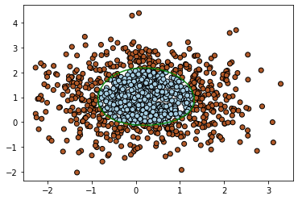

```python
plt.scatter(X[:, 0], X[:, 1], c=y, cmap=plt.cm.Paired, edgecolors='k')

ax = plt.gca()
xlim = ax.get_xlim()
ylim = ax.get_ylim()

# create grid to evaluate model
xx = np.linspace(xlim[0], xlim[1], 30)
yy = np.linspace(ylim[0], ylim[1], 30)
YY, XX = np.meshgrid(yy, xx)
xy = np.vstack([XX.ravel(), YY.ravel()]).T

# get the separating hyperplane
Z = clf.decision_function(xy).reshape(XX.shape)
# plot decision boundary and margins
a = ax.contour(XX, YY, Z, colors='g', levels=[0], alpha=0.9, linestyles=['-'])

plt.show()
```

Porównianie kształtu granicy decyzyjnej (rbf) dla C= 1,10,100,1000

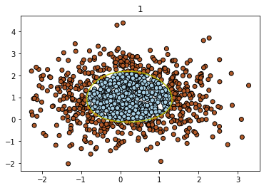

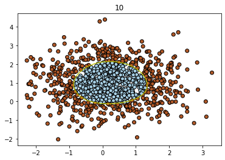

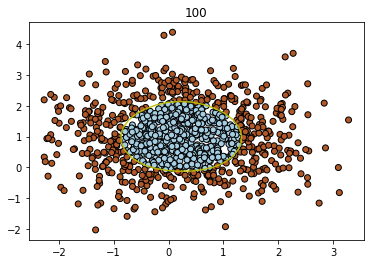

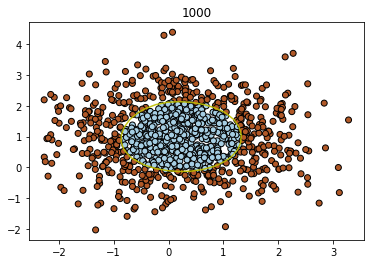

```python
C = [1,10,100,1000]
for c in C:
    clf = svm.SVC(C=c)
    clf.fit(X, y)
    SVC()
    plt.scatter(X[:, 0], X[:, 1], c=y, cmap=plt.cm.Paired, edgecolors='k')

    ax = plt.gca()
    xlim = ax.get_xlim()
    ylim = ax.get_ylim()

    xx = np.linspace(xlim[0], xlim[1], 30)
    yy = np.linspace(ylim[0], ylim[1], 30)
    YY, XX = np.meshgrid(yy, xx)
    xy = np.vstack([XX.ravel(), YY.ravel()]).T

    Z = clf.decision_function(xy).reshape(XX.shape)
    a = ax.contour(XX, YY, Z, colors='y', levels=[0], alpha=0.9, linestyles=['-'])
    plt.title(str(c))
    plt.show()
```

W przypadku wybrania funkcji rbf, różnica w kształcie granicy decyzyjnej nie znacząca

Porówanie kształtu granicy decyzyjnej (liniowe jądro) dla C=1,10,100,1000

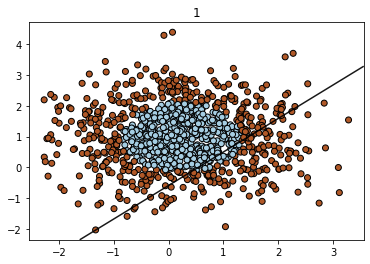

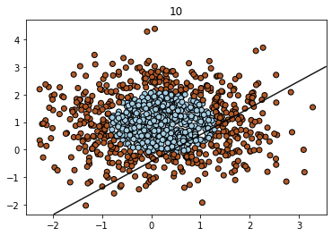

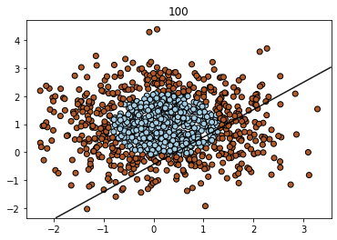

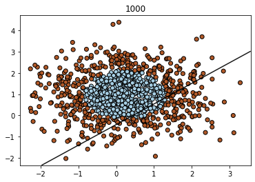

```python
C = [1,10,100,1000]
for c in C:
    clf = svm.SVC(kernel='linear', C=c)
    clf.fit(X, y)
    SVC()
    plt.scatter(X[:, 0], X[:, 1], c=y, cmap=plt.cm.Paired, edgecolors='k')

    ax = plt.gca()
    xlim = ax.get_xlim()
    ylim = ax.get_ylim()

    xx = np.linspace(xlim[0], xlim[1], 30)
    yy = np.linspace(ylim[0], ylim[1], 30)
    YY, XX = np.meshgrid(yy, xx)
    xy = np.vstack([XX.ravel(), YY.ravel()]).T

    Z = clf.decision_function(xy).reshape(XX.shape)
    a = ax.contour(XX, YY, Z, colors='k', levels=[0], alpha=0.9, linestyles=['-'])
    plt.title(str(c))
    plt.show()
```

W przypadku liniowej funkcji, występuje różnica w dopasowaniu prostej, natomiast różnnica jest najbardziej widoczna dla C=1.

Porównanie kształtu granicy decyzyjnej dla czterech dostepnych funkcji jądra (‘linear’, ‘poly’, ‘sigmoid’)

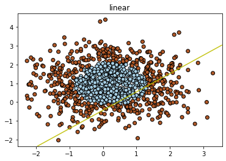

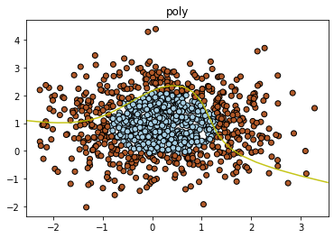

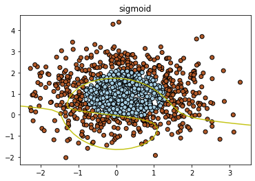

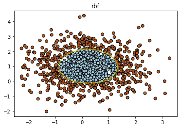

```python
f = ['linear','poly','sigmoid','rbf']
for funkcja in f:
    clf = svm.SVC(kernel=funkcja, C=100)
    clf.fit(X, y)
    SVC()
    plt.scatter(X[:, 0], X[:, 1], c=y, cmap=plt.cm.Paired, edgecolors='k')

    ax = plt.gca()
    xlim = ax.get_xlim()
    ylim = ax.get_ylim()

    xx = np.linspace(xlim[0], xlim[1], 30)
    yy = np.linspace(ylim[0], ylim[1], 30)
    YY, XX = np.meshgrid(yy, xx)
    xy = np.vstack([XX.ravel(), YY.ravel()]).T

    Z = clf.decision_function(xy).reshape(XX.shape)
    a = ax.contour(XX, YY, Z, colors='y', levels=[0], alpha=0.9, linestyles=['-'])
    plt.title(funkcja)
    plt.show()
```

# Ćwiczenie 2

Wczytanie bazy danych

```python
data =  pd.read_csv("HTRU_2.csv", header=None)
data.head()
```

|  | 0 | 1 | 2 | 3 | 4 | 5 | 6 | 7 | 8 |
| --- | --- | --- | --- | --- | --- | --- | --- | --- | --- |
| 0 | 140.562500 | 55.683782 | -0.234571 | -0.699648 | 3.199833 | 19.110426 | 7.975532 | 74.242225 | 0 |
| 1 | 102.507812 | 58.882430 | 0.465318 | -0.515088 | 1.677258 | 14.860146 | 10.576487 | 127.393580 | 0 |
| 2 | 103.015625 | 39.341649 | 0.323328 | 1.051164 | 3.121237 | 21.744669 | 7.735822 | 63.171909 | 0 |
| 3 | 136.750000 | 57.178449 | -0.068415 | -0.636238 | 3.642977 | 20.959280 | 6.896499 | 53.593661 | 0 |
| 4 | 88.726562 | 40.672225 | 0.600866 | 1.123492 | 1.178930 | 11.468720 | 14.269573 | 252.567306 | 0 |

Sprawdzenie brakujących wartości dla każdej z kolumn

```python
data.isnull().sum()
```

```
0    0
1    0
2    0
3    0
4    0
5    0
6    0
7    0
8    0
dtype: int64
```

```python
data2 = data.copy()
```

Usuwanie obserwacji odstających. Za obserwacje, które można podejrzewać, że są odstające, uważa się te, których atrybuty wykraczają poza przedział (Q1–1,5RQ, Q3+1,5RQ)

```python
for kolumna in data2.columns:
    Q1 = data2[kolumna].quantile(0.25)
    Q3 = data2[kolumna].quantile(0.75)
    IQR = Q3 - Q1
    A = Q1 - 1.5 * IQR
    B = Q3 + 1.5 * IQR
    mask = data2[kolumna].between(A, B, inclusive=True)
    mask = mask.to_numpy()
    for i in range(len(mask)):
        if (mask[i] == False):
            try:
                data2 = data2.drop([i], axis=0)
            except:
                pass
```

Zbiór z usuniętymi obserwacjami odstającymi

```python
data2.shape
```

```
(11313, 9)
```

Zbiór pełny

```python
data.shape
```

```
(17898, 9)
```

Normalizacja za pomocą średniej

```python
for kolumna in data2.columns[0:-2]:
    data2[kolumna] = (data2[kolumna]-data2[kolumna].mean())/data2[kolumna].std()
```

```python
data2.head()
```

|  | 0 | 1 | 2 | 3 | 4 | 5 | 6 | 7 | 8 |
| --- | --- | --- | --- | --- | --- | --- | --- | --- | --- |
| 0 | 1.402235 | 1.395360 | -1.238055 | -0.919549 | -0.243733 | -0.270157 | -0.199444 | 74.242225 | 0 |
| 1 | -0.725811 | 1.917963 | 0.550905 | -0.775940 | -0.308649 | -0.515197 | 0.403516 | 127.393580 | 0 |
| 2 | -0.697414 | -1.274657 | 0.187970 | 0.442781 | -0.247084 | -0.118287 | -0.255015 | 63.171909 | 0 |
| 3 | 1.189037 | 1.639562 | -0.813349 | -0.870209 | -0.224839 | -0.163566 | -0.449589 | 53.593661 | 0 |
| 4 | -1.496469 | -1.057264 | 0.897373 | 0.499060 | -0.329895 | -0.710721 | 1.259656 | 252.567306 | 0 |

```python
for kolumna in data.columns[0:-2]:
    data[kolumna] = (data[kolumna]-data[kolumna].mean())/data[kolumna].std()
```

```python
data.head()
```

|  | 0 | 1 | 2 | 3 | 4 | 5 | 6 | 7 | 8 |
| --- | --- | --- | --- | --- | --- | --- | --- | --- | --- |
| 0 | 1.149285 | 1.334794 | -0.669551 | -0.400448 | -0.319431 | -0.370615 | -0.072796 | 74.242225 | 0 |
| 1 | -0.334159 | 1.802215 | -0.011784 | -0.370525 | -0.371092 | -0.588908 | 0.504413 | 127.393580 | 0 |
| 2 | -0.314363 | -1.053293 | -0.145229 | -0.116590 | -0.322098 | -0.235322 | -0.125993 | 63.171909 | 0 |
| 3 | 1.000666 | 1.553211 | -0.513394 | -0.390167 | -0.304396 | -0.275659 | -0.312257 | 53.593661 | 0 |
| 4 | -0.871378 | -0.858855 | 0.115605 | -0.104863 | -0.388000 | -0.763090 | 1.323989 | 252.567306 | 0 |

Podział na dane testowe i treningowe

```python
labels1 = data[8].values #ostatnia kolumna to etykieta klasy
labels2 = data2[8].values #ostatnia kolumna to etykieta klasy
```

```python
data.drop([8],axis=1,inplace = True)
data2.drop([8],axis=1,inplace = True)
```

```python
features1 = data.values
features2 = data2.values
```

```python
x_data_train, x_data_test, y_data_train, y_data_test  = train_test_split(features1,labels1,test_size=0.2,random_state=75)
```

```python
x_data2_train, x_data2_test, y_data2_train, y_data2_test  = train_test_split(features2,labels2,test_size=0.2,random_state=75)
```

```python
y_data_test
```

```
array([0, 0, 0, ..., 0, 0, 0])
```

Accuracy dla C=1 i 1000 oraz funckji jądra 'rbf' oraz 'linear' (na zbiorze z uciętymi wartościami odstającymi)

```python
clf_l1 = svm.SVC(kernel='linear', C=1.0)
clf_r1 = svm.SVC(C=1.0)
clf_l1000 = svm.SVC(kernel='linear', C=1000)
clf_r1000 = svm.SVC(C=1000)
```

```python
clf_l1.fit(x_data2_train,y_data2_train)
```

```
SVC(C=1.0, break_ties=False, cache_size=200, class_weight=None, coef0=0.0,
    decision_function_shape='ovr', degree=3, gamma='scale', kernel='linear',
    max_iter=-1, probability=False, random_state=None, shrinking=True,
    tol=0.001, verbose=False)
```

```python
clf_r1.fit(x_data2_train,y_data2_train)
```

```
SVC(C=1.0, break_ties=False, cache_size=200, class_weight=None, coef0=0.0,
    decision_function_shape='ovr', degree=3, gamma='scale', kernel='rbf',
    max_iter=-1, probability=False, random_state=None, shrinking=True,
    tol=0.001, verbose=False)
```

```python
clf_l1000.fit(x_data2_train,y_data2_train)
```

```
SVC(C=1000, break_ties=False, cache_size=200, class_weight=None, coef0=0.0,
    decision_function_shape='ovr', degree=3, gamma='scale', kernel='linear',
    max_iter=-1, probability=False, random_state=None, shrinking=True,
    tol=0.001, verbose=False)
```

```python
clf_r1000.fit(x_data2_train,y_data2_train)
```

```
SVC(C=1000, break_ties=False, cache_size=200, class_weight=None, coef0=0.0,
    decision_function_shape='ovr', degree=3, gamma='scale', kernel='rbf',
    max_iter=-1, probability=False, random_state=None, shrinking=True,
    tol=0.001, verbose=False)
```

```python
ypred_l1 = clf_l1.predict(x_data2_test)
ypred_r1 = clf_r1.predict(x_data2_test)
ypred_l1000 = clf_l1000.predict(x_data2_test)
ypred_r1000 = clf_r1000.predict(x_data2_test)
```

```python
from sklearn.metrics import confusion_matrix
from sklearn.metrics import accuracy_score
```

```python
clfl1_score = clf_l1.score(x_data2_test,y_data2_test)
clfr1_score = clf_r1.score(x_data2_test,y_data2_test)
clfl1000_score = clf_l1000.score(x_data2_test,y_data2_test)
clfr1000_score = clf_r1000.score(x_data2_test,y_data2_test)
```

```python
accur = {'C': [1,1000],
    'linear':  [clfl1_score, clfl1000_score],
        'rbf': [clfr1_score, clfr1000_score]}

df = pd.DataFrame (accur, columns = ['C','linear','rbf'])
```

```python
df
```

|  | C | linear | rbf |
| --- | --- | --- | --- |
| 0 | 1 | 0.977022 | 0.959346 |
| 1 | 1000 | 0.976580 | 0.975254 |

Nauczony klasyfikator osiągnął najlepszy wynik dla C=1 i jądra liniowego, natomiast wartości są bardzo do siebie zbliżone

Określenie confusion matrix

```python
confusion_matrix(y_data2_test,ypred_l1)
```

```
array([[2165,    6],
       [  46,   46]])
```

Chcemy dążyć do macierzy, w której pierwszy wiersz w pierwszej kolumnie będzie miał największą wartość, najlepiej gdyby poza przekątną macierzy występowały same 0.

```python
from sklearn.metrics import plot_roc_curve
```

Rysowanie krzywej ROC

```
<sklearn.metrics._plot.roc_curve.RocCurveDisplay at 0x7f4b55cc2f98>
```

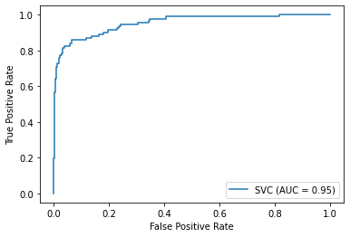

```python
plot_roc_curve(clf_l1,x_data2_test,y_data2_test)
```

Obliczenie pola pod krzywą

```python
from sklearn.metrics import auc
from sklearn.metrics import roc_curve
```

```python
f,t,thre = roc_curve(y_data2_test, ypred_l1)
```

```python
auc(f,t) #Wartość pola pod krzywą
```

```
0.7486181483187472
```